# hw question #2

Varun Venkatesh

2025-04-07

## part A

About 64.8% of those who received a GOTV call voted in 1998.

About 44.4% of those who did not receive a GOTV call voted in 1998.

The difference in proportions is approximately 20.35 percentage points.

The 95% confidence interval for the difference is approximately [0.1432, 0.2638].

This indicates that receiving a GOTV call is associated with a statistically significant increase in the likelihood of voting in 1998.

Calculating Proportions: The proportion of those who voted in 1998 is computed separately for individuals with and without a GOTV call using the mean() function (which works because voted1998 is coded as 0/1).

Difference & Standard Error: The difference in proportions is computed and then the standard error is calculated using the formula: SE= sqrt(p1(1-p1)/n1 + p2(1-p2)/n2) Confidence Interval: A 95% confidence interval is constructed using the formula:

Difference ± 1.96 x SE

## part B

```r
# Read in the data
data <- read.csv("turnout.csv")


# 1. Summary statistics by GOTV_call

# Create a summary table for voted1996, AGE, and MAJORPTY by GOTV_call
summary_stats <- aggregate(cbind(voted1996, AGE, MAJORPTY) ~ GOTV_call, data = data, FUN = mean)
print(summary_stats)
```

```
##   GOTV_call voted1996      AGE  MAJORPTY
## 1         0 0.5308070 49.42534 0.7447552
## 2         1 0.7125506 58.30769 0.8016194
```

```r
# 2. Calculate differences and 95% CIs for each confounder


# Set z-score for 95% CI (large-sample approximation)
z <- 1.96

# (a) Prior voting in 1996 (binary)
prop_voted1996_called <- mean(data$voted1996[data$GOTV_call == 1])
prop_voted1996_not_called <- mean(data$voted1996[data$GOTV_call == 0])
diff_voted1996 <- prop_voted1996_called - prop_voted1996_not_called
n_called <- sum(data$GOTV_call == 1)
n_not_called <- sum(data$GOTV_call == 0)
se_voted1996 <- sqrt((prop_voted1996_called * (1 - prop_voted1996_called) / n_called) +
                       (prop_voted1996_not_called * (1 - prop_voted1996_not_called) / n_not_called))
ci_voted1996_lower <- diff_voted1996 - z * se_voted1996
ci_voted1996_upper <- diff_voted1996 + z * se_voted1996

cat("Difference in 1996 voting proportions (GOTV - No GOTV):", diff_voted1996, "\n")
```

```
## Difference in 1996 voting proportions (GOTV - No GOTV): 0.1817436
```

```r
cat("95% CI: [", ci_voted1996_lower, ",", ci_voted1996_upper, "]\n\n")
```

```
## 95% CI: [ 0.124507 , 0.2389801 ]
```

```r
# (b) AGE (continuous)
mean_age_called <- mean(data$AGE[data$GOTV_call == 1])
mean_age_not_called <- mean(data$AGE[data$GOTV_call == 0])
diff_age <- mean_age_called - mean_age_not_called

# Use a two-sample t-test for AGE difference and CI (large-sample approximation is appropriate with large n)
t_age <- t.test(AGE ~ GOTV_call, data = data)
cat("Difference in mean AGE (GOTV - No GOTV):", diff_age, "\n")
```

```
## Difference in mean AGE (GOTV - No GOTV): 8.882347
```

```r
cat("95% CI (from t-test): [", t_age$conf.int[1], ",", t_age$conf.int[2], "]\n\n")
```

```
## 95% CI (from t-test): [ -11.39505 , -6.369644 ]
```

```r
# (c) MAJORPTY (binary)
prop_majorpty_called <- mean(data$MAJORPTY[data$GOTV_call == 1])
prop_majorpty_not_called <- mean(data$MAJORPTY[data$GOTV_call == 0])
diff_majorpty <- prop_majorpty_called - prop_majorpty_not_called
se_majorpty <- sqrt((prop_majorpty_called * (1 - prop_majorpty_called) / n_called) +
                      (prop_majorpty_not_called * (1 - prop_majorpty_not_called) / n_not_called))
ci_majorpty_lower <- diff_majorpty - z * se_majorpty
ci_majorpty_upper <- diff_majorpty + z * se_majorpty

cat("Difference in MAJORPTY proportions (GOTV - No GOTV):", diff_majorpty, "\n")
```

```
## Difference in MAJORPTY proportions (GOTV - No GOTV): 0.05686419
```

```r
cat("95% CI: [", ci_majorpty_lower, ",", ci_majorpty_upper, "]\n")
```

```
## 95% CI: [ 0.006442534 , 0.1072858 ]
```

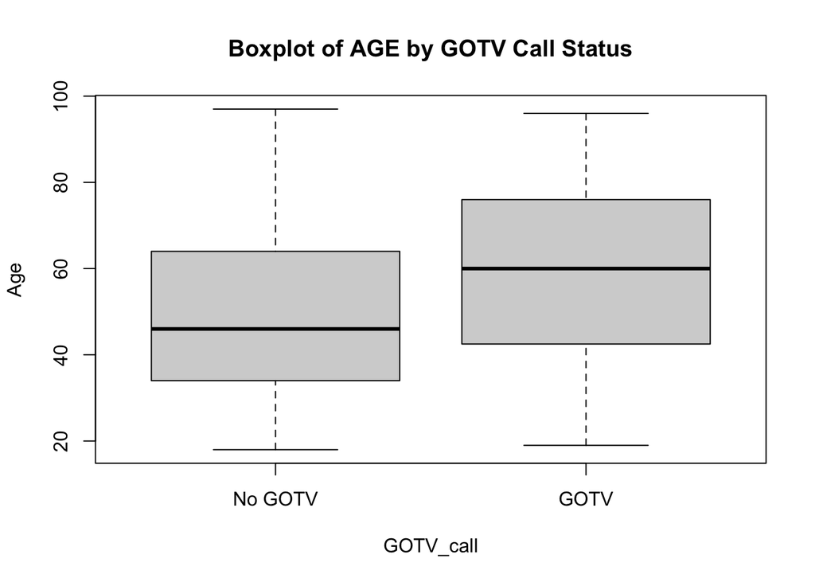

```r
# 3.Plotting

# Plot AGE distribution by GOTV_call
boxplot(AGE ~ GOTV_call, data = data,
        names = c("No GOTV", "GOTV"),
        main = "Boxplot of AGE by GOTV Call Status",
        ylab = "Age")
```

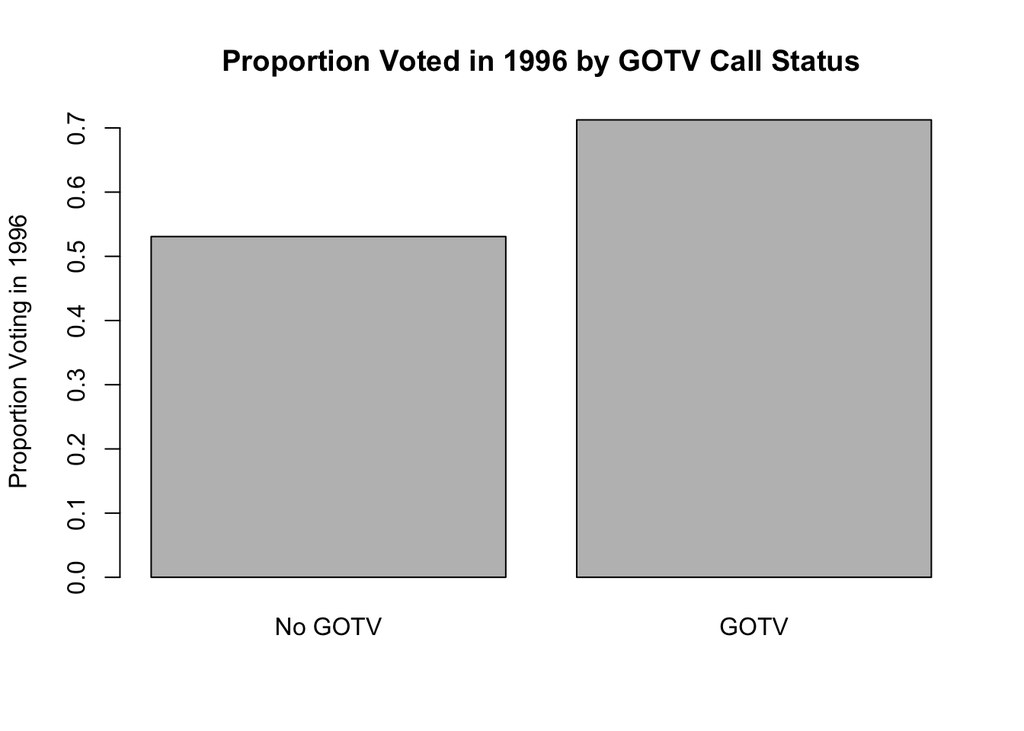

```r
# Barplot for voted1996 proportions by GOTV_call
prop_voted1996 <- tapply(data$voted1996, data$GOTV_call, mean)
barplot(prop_voted1996,
        names.arg = c("No GOTV", "GOTV"),
        main = "Proportion Voted in 1996 by GOTV Call Status",
        ylab = "Proportion Voting in 1996")
```

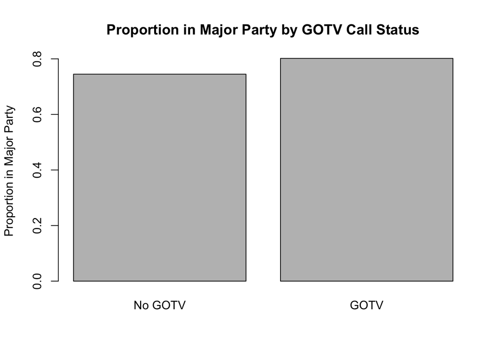

```r
# Barplot for MAJORPTY proportions by GOTV_call
prop_majorpty <- tapply(data$MAJORPTY, data$GOTV_call, mean)
barplot(prop_majorpty,
        names.arg = c("No GOTV", "GOTV"),
        main = "Proportion in Major Party by GOTV Call Status",
        ylab = "Proportion in Major Party")
```

Prior Voting (voted1996):

No GOTV Call: I observed that about 53.1% voted in 1996.

GOTV Call: I observed that about 71.2% voted in 1996.

Difference: Those who received the call were about 18.2 percentage points more likely to have voted in 1996.

95% CI: [12.45%, 23.90%].

This indicates that the call group already had a higher voting rate before the campaign.

Age (AGE):

No GOTV Call: The average age is about 49.43 years.

GOTV Call: The average age is about 58.31 years.

Difference: The GOTV group is roughly 8.9 years older.

Note: A t-test might show a negative number if I reverse the order of subtraction, but it is clear that the call group is older.

Major Party Registration (MAJORPTY):

No GOTV Call: About 74.5% are registered with a major party.

GOTV Call: About 80.2% are registered with a major party.

Difference: There is a 5.7 percentage point higher registration rate in the GOTV group.

95% CI: [0.64%, 10.73%].

Why It Matters:

These differences show that the people who received the GOTV call were already different—they were more likely to vote before, they were older, and they were more often registered with a major party. Since these factors also make someone more likely to vote in 1998, they confound the effect of the GOTV call. This means that the simple difference in 1998 voting rates might not be solely due to the GOTV call; it could also be because the two groups differ in these important ways.

## part C

```
## [1] "Balance Table (Means by GOTV_call):"
```

```
##   GOTV_call voted1996      AGE  MAJORPTY
## 1         0 0.7125506 58.26640 0.8072874
## 2         1 0.7125506 58.30769 0.8016194
```

```
## Matched difference in voted1996 (Treated - Control): 0
```

```
## 95% CI: -0.06182822 to 0.06182822
```

```
## Matched difference in AGE (as reported by t.test): -0.04129555
```

```
## 95% CI for AGE difference: -2.760374 to 2.677783
```

```
## Matched difference in MAJORPTY (Treated - Control): -0.005668016
```

```
## 95% CI: -0.06004875 to 0.04871271
```

```
## Matched Proportion of 1998 voting (Treated): 0.6477733
```

```
## Matched Proportion of 1998 voting (Control): 0.5692308
```

```
## Matched difference in 1998 voting (Treated - Control): 0.07854251
```

```
## 95% CI for difference: 0.01288148 to 0.1442035
```

Balance Check (voted1996, AGE, MAJORPTY):

voted1996: I found that the difference between the treated and control groups is near zero, and the confidence interval includes zero.

AGE: The difference is about –0.04 years, and its 95% confidence interval also spans zero.

MAJORPTY: The difference is about –0.006, with the 95% confidence interval crossing zero.

These very small differences (all close to 0) show that my matched sample is balanced—the treated and control groups look almost identical in terms of prior voting, age, and party registration.

Effect on 1998 Voting (voted1998):

Treated (GOTV_call = 1): About 64.8% voted in 1998.

Control (GOTV_call = 0): About 56.9% voted in 1998.

Difference: The difference is about 7.85 percentage points, with a 95% confidence interval roughly between [1.29%, 14.42%].

This difference (≈8%) is smaller than the naive difference (≈20%) I saw before matching. After controlling for the confounders, I still see a positive effect of the GOTV call on 1998 voting, but it is more modest once I account for differences in prior voting history, age, and party registration.